# Informe Primer Semestre 2021

Lenguaje y Comunicación

Claudio Rojas. Director Académico

2021-07-31

## 0.1 Presentación

El presente informe tiene como objetivo revisar el trabajo del sector, a través de información que sistematiza los resultados académicos del I semestre y recoge lo proyectado para el II semestre del presente año, considerando las definiciones claves que tenemos como colegio pero también como una institución de la Compañía de Jesús.

Este informe incluye:

- Definiciones Clases
- Informe de Notas
- Metas de Aprendizaje.
- Propuestas de Evaluación II Semestre.

Cada una de las partes de informe incluye sugerencias que bucan orientar la reflexión y práctica del sector para poder realizar los ajustes que sean necesarios para el trabajo de la segunda parte del presente año.

## 0.2 Definiciones Claves

Les recuerdo tener presente las definiciones claves tanto a nivel de red ignaciana como interna que deben siempre orientar nuestro trabajo académico.

### 0.2.1 Envío 3 Planificación Estratégica de los colegios Jesuitas

Asegurar que los 10 colegios y escuelas jesuitas desarrollen las prácticas y procesos necesarios para ofrecer la excelencia académica propia de una comprensión ignaciana de la educación de calidad.

### 0.2.2 Nuestra Definición de Calidad

Nosotros, como comunidad sanjavierina, entendemos por educación de calidad todo aprendizaje que nos lleva a descubrir y desarrollar nuestras capacidades de manera integral, formándonos como personas competentes, conscientes, comprometidas, compasivas y creativas, para así conocer y amar más y mejor a Jesucristo, sirviendo a nuestros hermanos en los diversos contextos sociales.

### 0.2.3 Nuestro Foco de Mejora

Fortalecer la propuesta curricular, con una didáctica renovada, bajo el Paradigma Pedagógico Ignaciano.

## 0.3 Informe de Notas

El informe de notas contiene la siguiente información:

- Tabla de Resumen de las notas por nivel.
- Notas de 1º básico a IVº medio.
- Distribución por Niveles de Logro.

En el caso de los resultados, les sugiero analizar:

- Los promedios finales obtenidos por cada nivel
- Cantidad de estudiantes que están en cada nivel de logro.
- Las diferencias de resultados entre hombres y mujeres.

### 0.3.1 Tabla de Resumen de Notas:

Esta tabla incluye la información de la asignatura por nivel en cuanto:

- Promedio de la asignatura.
- Nota Mínima.
- Mediana.
- Nota Máxima.

[output not shown]

### 0.3.2 Notas de 1º básico a IVº medio

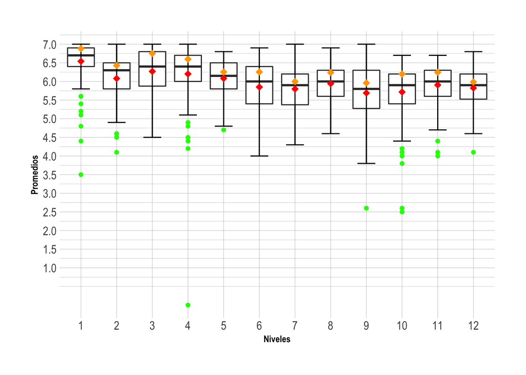

### 0.3.3 Distribución de Estudiantes por Niveles de Logro y diferenciado por Sexo.

#### 0.3.3.1 Primeros Básicos

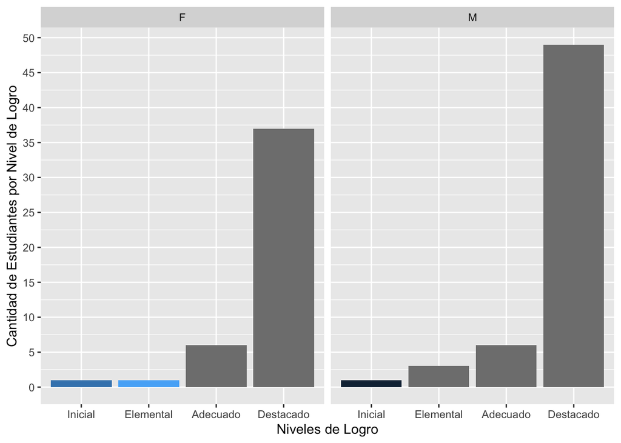

### Segundos Básicos

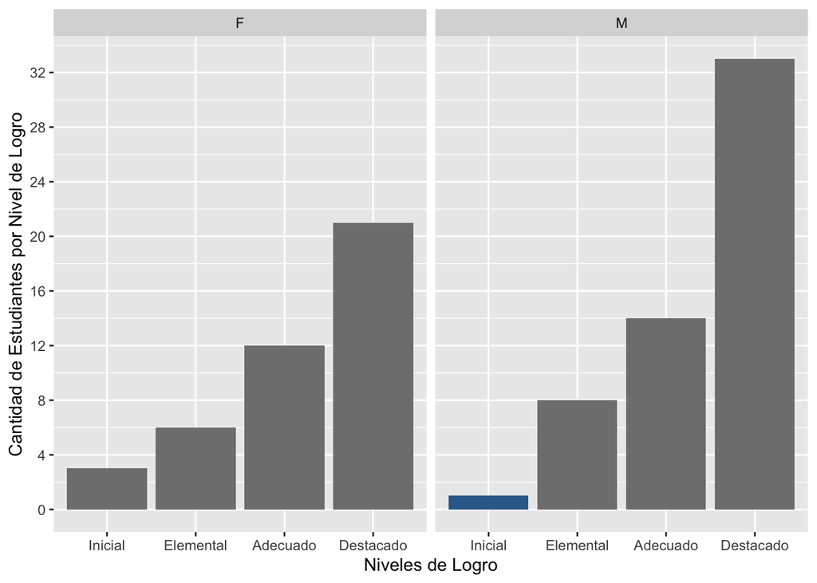

#### 0.3.3.2 Terceros Básicos

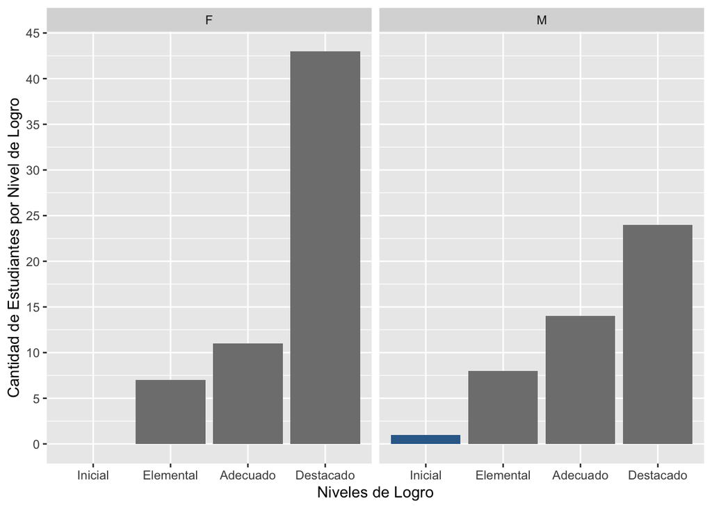

#### 0.3.3.3 Cuartos Básicos

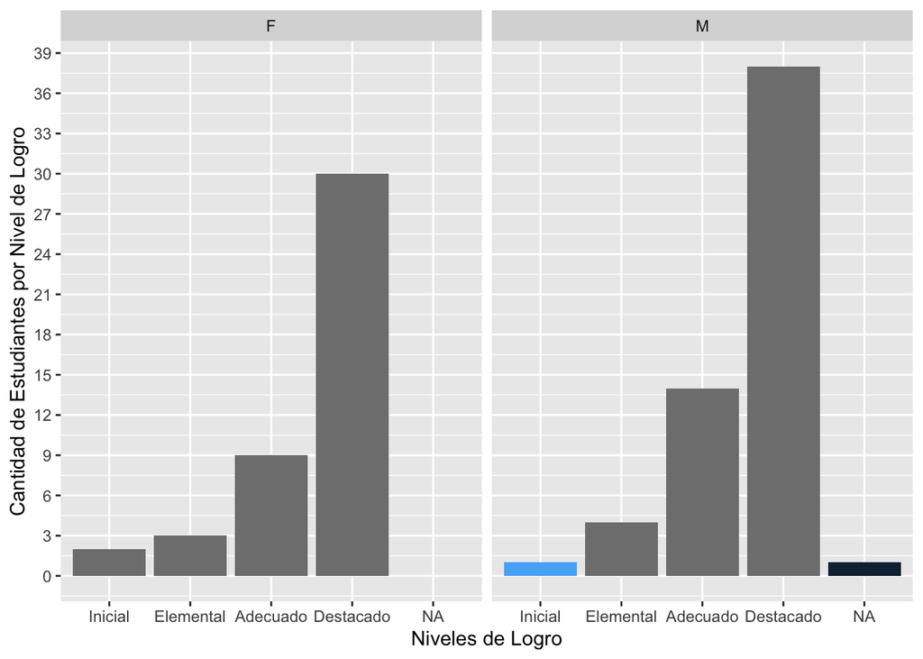

#### 0.3.3.4 Quintos Básicos

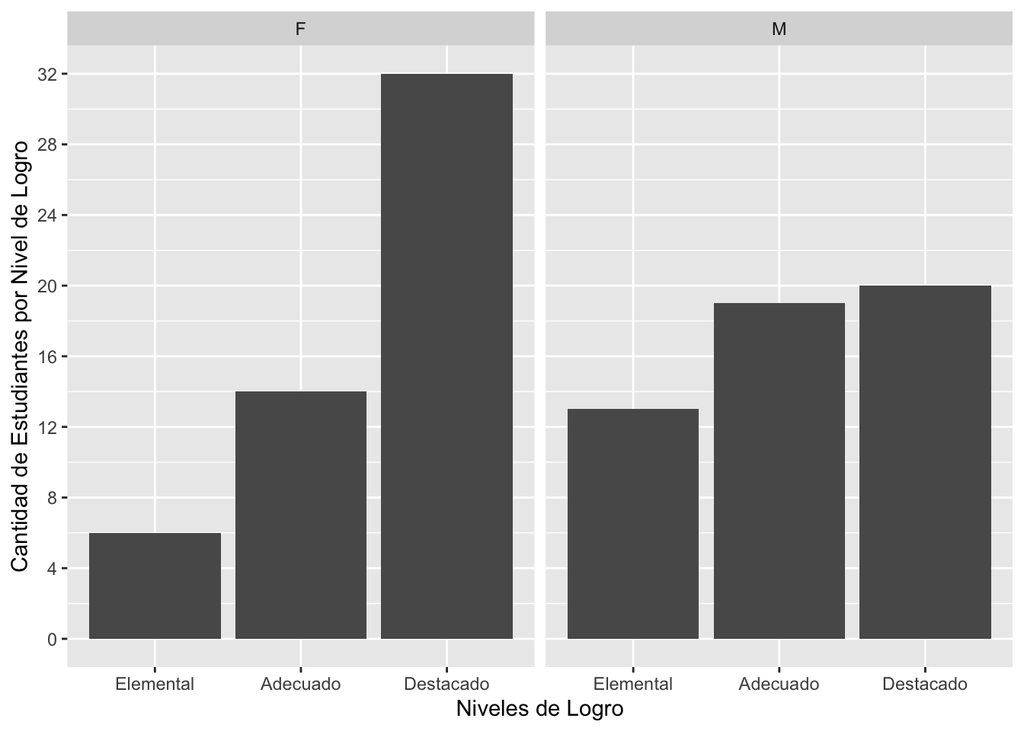

#### 0.3.3.5 Sextos Básicos

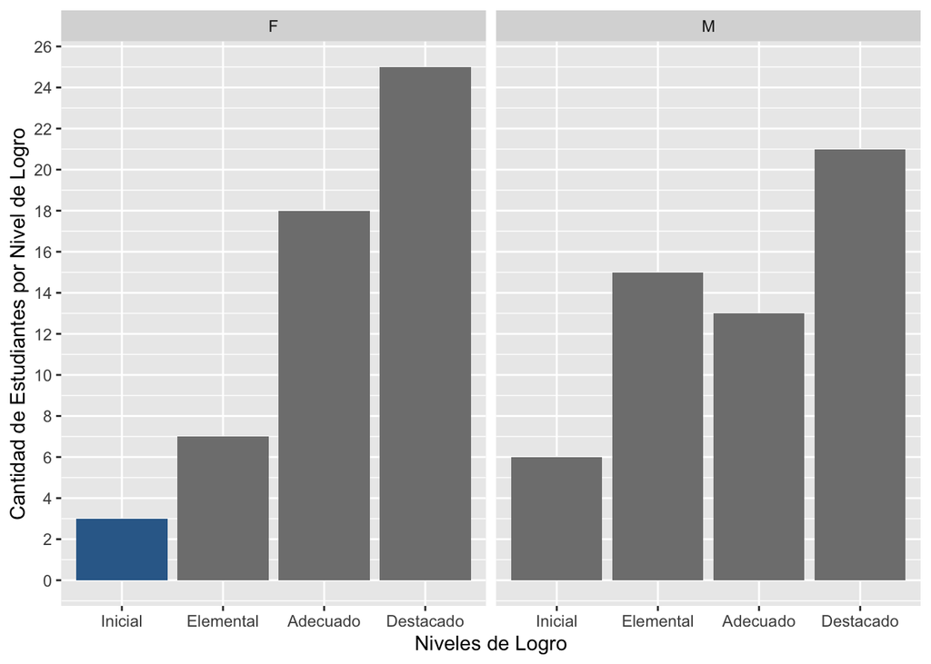

#### 0.3.3.6 Séptimos Básicos

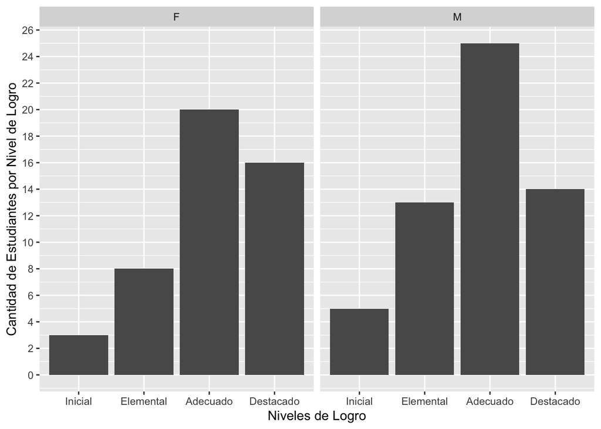

#### 0.3.3.7 Octavos Básicos

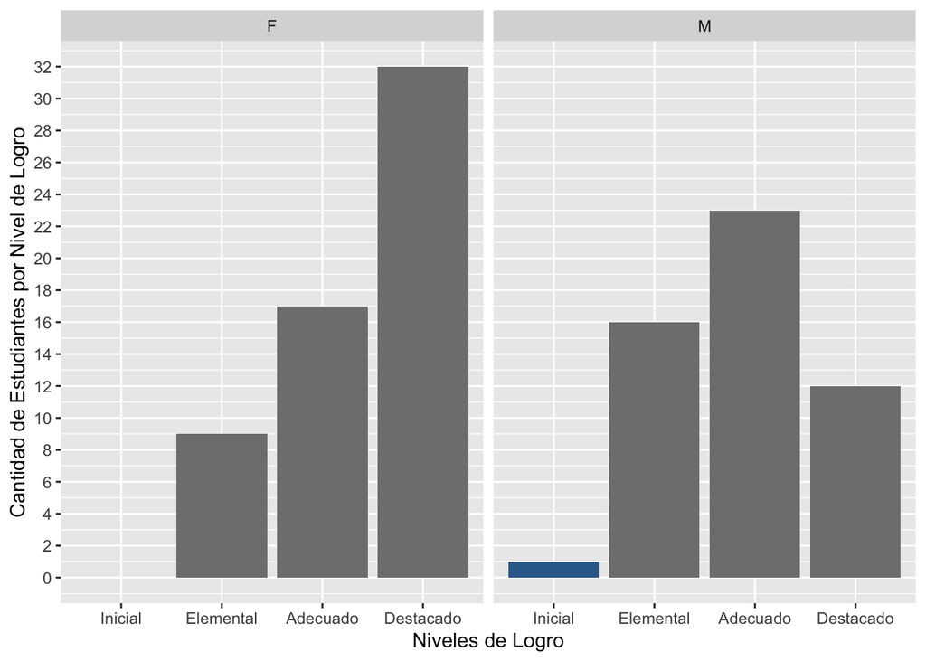

#### 0.3.3.8 Primeros Medios

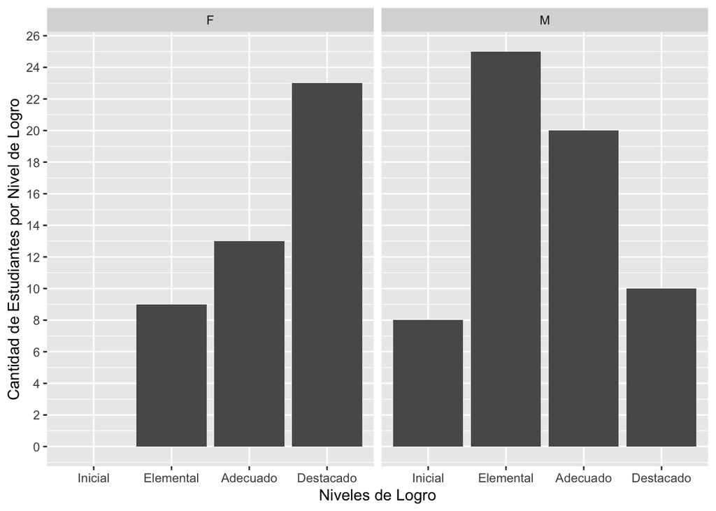

#### 0.3.3.9 Segundos Medios

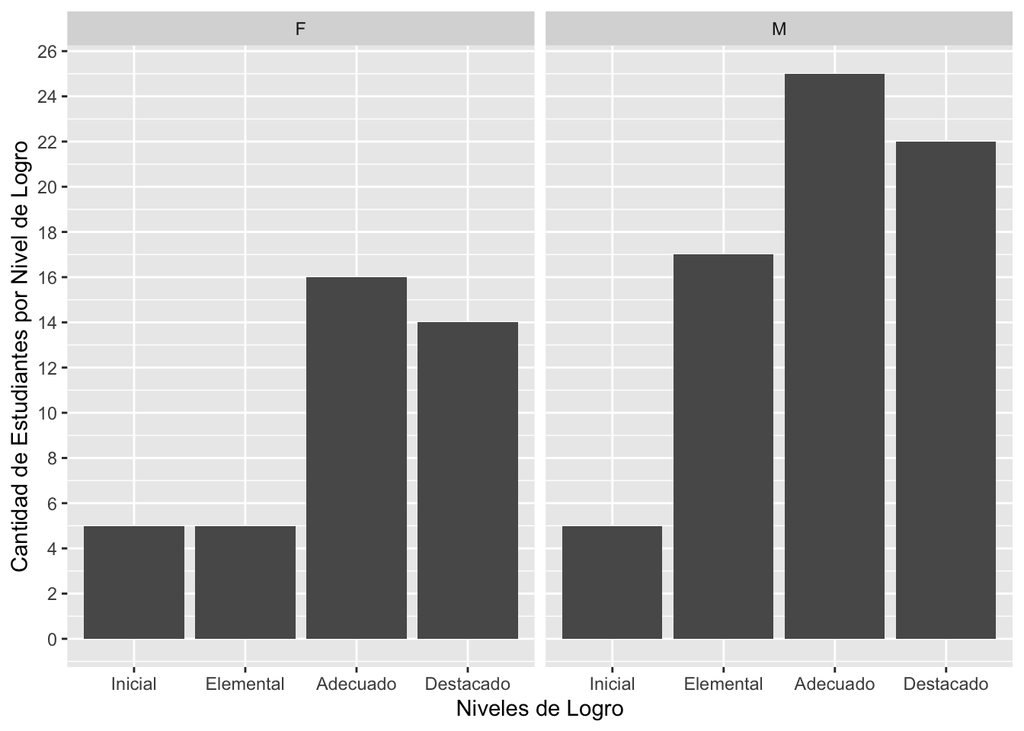

#### 0.3.3.10 Terceros Medios

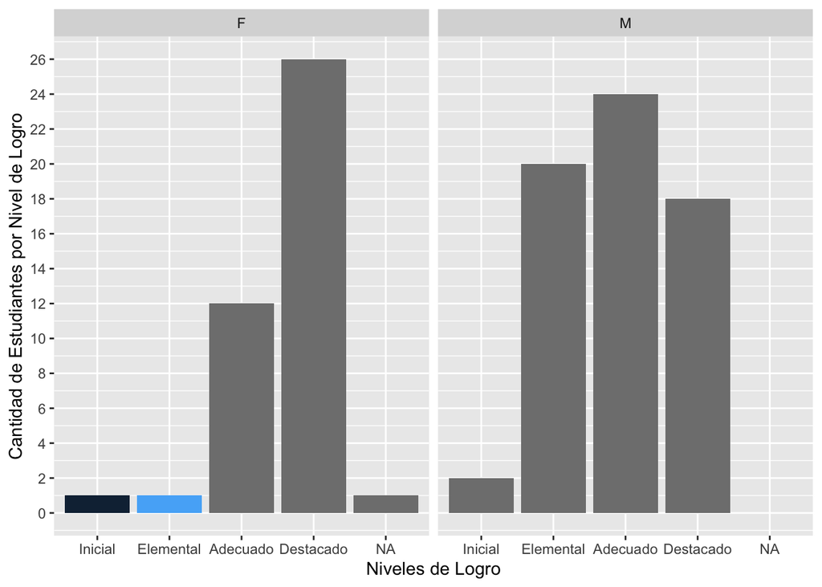

#### 0.3.3.11 Cuartos Medios

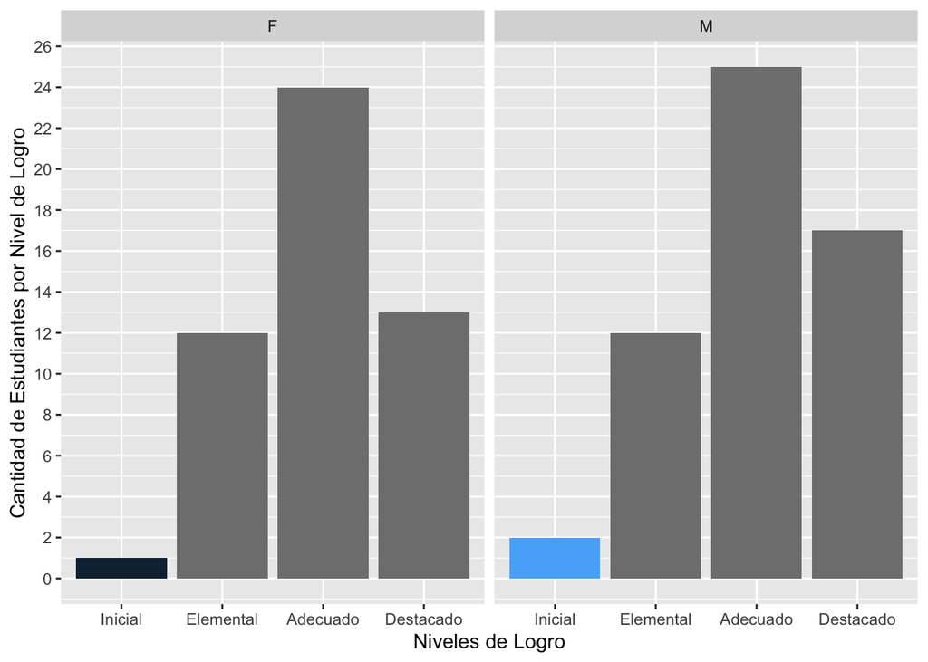

## 0.4 Metas de Aprendizajes

- **¿Contienen errores gramaticales:** **Redacción, Faltas de Ortografía** **?**
- **¿Se usan los verbos adecuados?** Ejemplo: *“Demuestran que leen y comprenden textos literarios y no literarios…” (Sexto Básico)* o *“Leer, analizar e interpretar y dialogar en torno a…” (Octavo Básico)*. **Priorizar verbos que engloben más una secuencia de éstos.**
- **¿Dan cuenta de aprendizajes relevantes que deben adquirir mis estudiantes? ¿Es coherente con el plan de estudios?**
- **¿Las metas dan cuenta solo de “saberes” (aprendizajes curriculares) o de desempeños a realizar con lo aprendido?** Ejemplo: *“Leen e identifican textos narrativos latinoamericanos, con el fin de analizar las características (…)” (Segundo medio)*. **¿Esto debe ser una meta o es parte para llegar a algo más?**
- **¿Por qué la meta de cuarto básico es similar para ambas unidades?**
- **Ajustar las metas que contengan verbos que son poco precisos a la hora de medir:** *Comprender, Reflexionar*. **Pero también, aquellas que contengan verbos que den cuenta de niveles básicos de aprendizaje:** *Identificar, Reconocer*. **Las metas de aprendizajes deben ser** *Medibles* **pero también** *Desafiantes*.

### 0.4.1 Metas de Aprendizajes Primer Ciclo

| Nivel | Segunda Unidad | Tercera Unidad |
| --- | --- | --- |
| Primero Básico | Se espera que los estudiantes comprendan que la lectura, escritura y escucha de narraciones nos ayudan a comprender que los textos transmiten información que nos permite reflexionar y opinar respecto … | Se espera que los estudiantes consoliden el proceso de lectoescritura leyendo en forma independiente y escribiendo diariamente oraciones completas para expresar sus ideas o compartir información en ba… |
| Segundo básico | Los estudiantes comprenderan que diversos textos (cuentos folclóricos, leyendas y artículos informativos) nos ayudan a interiorizarnos con nuestro país. | Los estudiantes observarán la naturaleza y su entorno para crear poemas y así expresar emociones que éstos les generan. |

### 0.4.2 Metas de Aprendizajes Segundo Ciclo

| Nivel | Segunda Unidad | Tercera Unidad |
| --- | --- | --- |
| Tercero básico | Los estudiantes demostrarán que comprenden variadas tipologías textuales, como noticia y textos informativos usando estrategias de comprensión (recuperación de la información, interpretar y reflexiona… | Los estudiantes demostrarán que comprenden y contrastan variadas tipologías textuales, como leyenda y mitos usando estrategias de comprensión (recuperación de la información, interpretar y reflexionar… |
| Cuarto básico | Demostrarán que leen y comprenden textos literarios y no literarios (cuentos folclóricos, noticia y biografía) utilizando estrategia de comprensión de lectura (recuperar información, interpretar- refl… | Demostrarán que leen y comprenden textos literarios y no literarios (cuentos folclóricos, noticia y biografía) utilizando estrategia de comprensión de lectura (recuperar información, interpretar- refl… |
| Quinto básico | Leen y comprenden textos no literarios ( noticias, artículo informativo e nfografías) utilizando estrategia de comprensión de lectura (recuperar información, interpretar- reflexionar y opinar) con el … | Expresarse de forma escrita u oral de manera clara y precisa, utilizando las diversas estrategias y estructuras trabajadas en clases. |
| Sexto básico | Demuestran que leen y comprenden textos literarios y no literarios (cuentos folclóricos, noticia y biografía) utilizando estrategia de comprensión de lectura (recuperar información, interpretar- refle… | Expresarse de forma escrita u oral de manera clara y precisa, utilizando las diversas estrategias y estructuras trabajadas en clases. |

En este caso, no se consideró cuarto medio porque su foco esta relevado a la prueba PDT.

| Nivel | Segunda Unidad | Tercera Unidad |
| --- | --- | --- |
| Séptimo básico | Analizar poemas (romances y poesía popular) para emitir de manera escrita y oral una opinión fundamentada sobre ellas. | Criticar textos de los medios de comunicación,tanto orales como escritos, para formar una opinión sobre la información que reciben, distingan las opiniones y hechos, aprendan a investigar antes de emi… |
| Octavo básico | Leer, analizar e interpretar y dialogar en torno a textos de misterio y policiales, aplicando las estrategias de comprensión en la lectura y escribiendo textos desaarrollando su creatividad y utilizan… | Reflexionar y realizar una lectura analítica y crítica de textos de medios de comunicación, tanto orales como escritos, formando una opinión y distinguiendola de los hechos.Investigando antes de emiti… |
| Primero medio | Analizan obras narrativas chilenas considerando: temas, conflictos, personajes tipo y estereotipo, ambiente y el contexto de producción en que se desarrollan. | Analizan poemas del Romanticismo considerando: símbolos, actitud del hablante, lenguaje figurado y relaciones intertextuales con otras obras. |
| Segundo medio | Leen e identifican textos narrativos latinoamericanos, con el fin de analizar las caracterísitcas propias del género, los recursos de estilo y las temáticas que plantean. | Leen e identifican textos líricos y dramáticos del Siglo de Oro, con el fin de analizar las caracterísitcas propias del género, los recursos de estilo y las temáticas propias de la época. |

## 0.5 Plan de Evaluación IIº semestre 2021

En la siguiente tabla se presentan los procedimientos e instrumentos declarados por el sector (1º básico en adelante) y la cantidad de veces que se repiten. Revisar lo declarado en el plan de evaluación considerando los siguientes criterios:

- ¿Hay claridad en el sector entre lo que es un procedimiento y su diferencia con el instrumento? **En el caso de dudas, revisar nuestro [Reglamento de Evaluación](https://www.colsanjavier.cl/files/documentos/REGLAMENTO%20INTERNO%20DE%20EVALUACIÓN%202021.%20%5Bv.%2030-04-2021%5D.pdf).**
- **¿Existe una diversidad de formas de evaluar o se limitan a la práctica recurrente de procedimientos e instrumentos utilizados en el sector?*** **En caso de lo que se declara como Plan Lector(Planl) ¿Cómo se evalúa? ¿Con pruebas, con trabajos, con disertaciones etc.?**

Por último, se agrega una nube de palabras que quiere reflejar la diversidad de instrumentos y el peso de cada uno de ellos.

|  | word | freq |
| --- | --- | --- |
| prueba | prueba | 19 |
| planl | planl | 11 |
| escritura | escritura | 10 |
| miniensayos | miniensayos | 8 |
| control | control | 4 |
| booktuber | booktuber | 4 |
| disertaciones | disertaciones | 3 |
| test | test | 3 |
| investigación | investigación | 2 |
| trabajo | trabajo | 2 |
| dictados | dictados | 1 |
| discurso | discurso | 1 |
| lapbook | lapbook | 1 |
| performance | performance | 1 |
| presentación | presentación | 1 |
| exposición | exposición | 1 |
| informe | informe | 1 |

[interactive chart not shown]

En el caso del **Plan de Nivel**, les solicito que como sector concuerden y plasmen en la planificación

- En qué sesiones se evaluarán el OA que se hace responsable el sector.
- El instrumento que usarán para concretar esta evaluación.

Es importante que ustedes como jefes de sector hagan sequimiento de este proceso, ya que es el medio con el cual concretamos la formación integral. Pero, además, los resultados obtenidos, es lo que informamos a los estudiantes y sus familias en los distintos objetivos de aprendizajes asociados a las tres dimensiones de nuestro Mapa de Formación Integral.

## 0.6 Planificación de Clases

Durante las siguientes dos semanas pondremos énfasis en la planificación. Por lo que es importante avanzar toda la unidad 2 durante este tiempo. Para organizar la planificación les sugiero pensar un modelo de clases que considere la siguiente estructura. Esto con el objetivo de asegurar el aprendizaje de sus estudiantes:

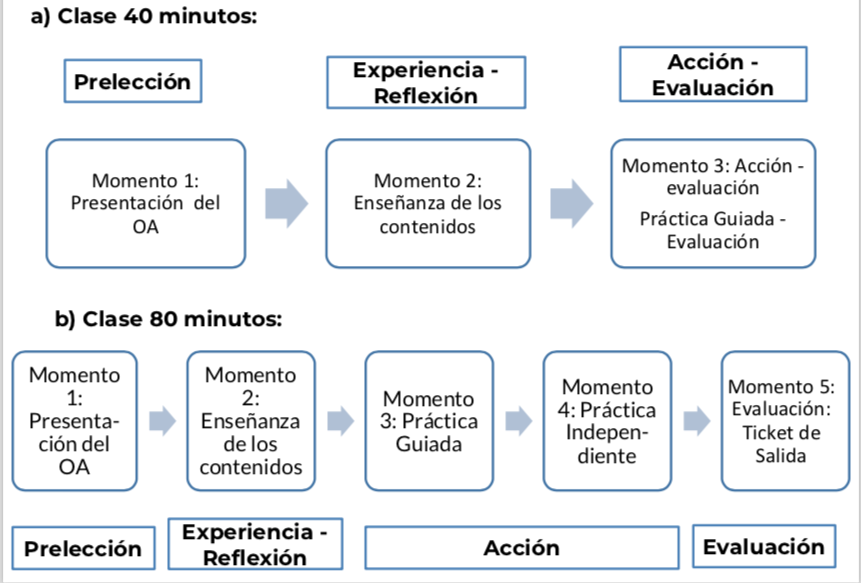

…